# 4.2 Axe économique : Revenu des ménages et abordabilité

Curbcut

# 4.2.1 Revenu total annuel médian selon la composition des ménages, le mode d’occupation et l’âge du principal soutien

*Source: Statistique Canada, Recensement de la population de 2021, analyse et traitement des données par Curbcut*

Le graphique suivant met en lumière les disparités de revenu entre les locataires et les propriétaires à Laval, en fonction de la composition du ménage. Les propriétaires ont des revenus médians supérieurs à ceux des locataires dans toutes les catégories de ménages. Cette tendance souligne une corrélation forte entre la possession d’un bien immobilier et un revenu annuel médian plus élevé, mettant en évidence les inégalités pour se constituer un patrimoine financier par l’immobilier selon son revenu.

Les couples avec enfants et les ménages multigénérationnels propriétaires sont les groupes disposant des revenus les plus élevés, avec des revenus annuels médians respectivement de 140 000 $ et de 147 000 $, probablement en raison de la contribution de plusieurs adultes au revenu familial.

Les familles monoparentales locataires et les locataires vivant seuls ont des revenus bien inférieurs à la médiane de 85 000 $ pour l’ensemble des ménages, représentant respectivement 0.71x et 0.42x de ce montant. Cela suggère une plus grande précarité économique pour ces groupes. Effectivement, les personnes seules locataires ont un revenu médian de 35 600 $, alors que celui des propriétaires vivant seul de 51 600 $. Par ailleurs, les personnes seules sont surreprésentées parmi les locataires, représentent 47,4 % des locataires, ce qui renforce leur vulnérabilité dans le marché locatif, notamment abordable, où l’offre est insuffisante et les ménages aux revenu plus élevé ont alors un avantage compétitif.

L’intensité de l’opacité des barres indique la proportion de ménages dans chaque catégorie, mettant ainsi en évidence les situations les plus courantes pour chaque statut d’occupation. Par exemple, bien que le revenu annuel médian des ménages multigénérationnels soit le plus élevé, ce groupe est minoritaire (3,6 %) en termes de nombre de ménages, d’où une opacité plus faible de la barre. En revanche, les barres des couples propriétaires avec enfants (40,1 %) et des locataires vivant seuls (47,4 %) sont plus foncées, car ces groupes sont les plus représentés selon leur statut d’occupation.

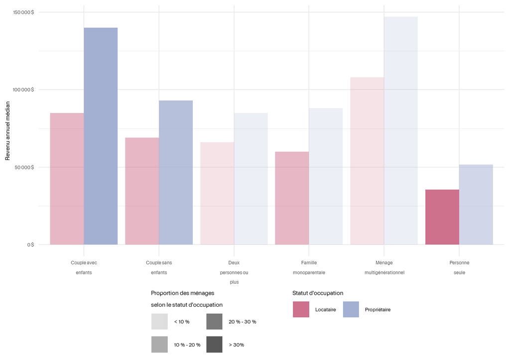

Revenu annuel médian par statut d’occupation et composition familiale

# 4.2.4 Montant du loyer/frais médian de logement en fonction du revenu et du mode d’occupation (axe “prix/revenu” de l’abordabilité)

*Source: Statistique Canada, Recensement de la population de 2021, analyse et traitement des données par Curbcut*

Pour les tranches de revenus inférieures à 60 000 $, les frais médian de logement des locataires sont systématiquement plus élevés que ceux des propriétaires. Dans la tranche de revenu de 20 - 39 999 $, celle la plus fréquente chez les locataires, les loyers mensuels médians sont de 810 $ (pour 15 010 ménages locataires) tandis qu’ils sont de 645 $ pour les 9 230 ménages propriétaires.

À partir de la tranche de revenu de 60 000 $ à 79 999 $, cette tendance s’inverse. Les propriétaires ont alors des frais de logement médians qui dépassent ceux des locataires, et l’écart continue de croître dans les tranches de revenus supérieures. Pour les revenus de 100 000 $ et plus, les propriétaires paient des frais médian de logement 41,9 % plus élevés que les locataires, ce qui peut s’expliquer par l’accession à des logements de plus grande valeur et les frais associés.

” Pour les ménages propriétaires, les frais de logement englobent, s’il y a lieu, les paiements hypothécaires, l’impôt foncier et les charges de copropriété (communément appelés frais de condominium), ainsi que les frais d’électricité, de chauffage, d’eau et des autres services municipaux. Pour les ménages locataires, les frais de logement englobent, s’il y a lieu, le loyer et les frais d’électricité, de chauffage, d’eau et des autres services municipaux. ” https://www12.statcan.gc.ca/census-recensement/2021/ref/dict/az/Definition-fra.cfm?ID=households-menage033

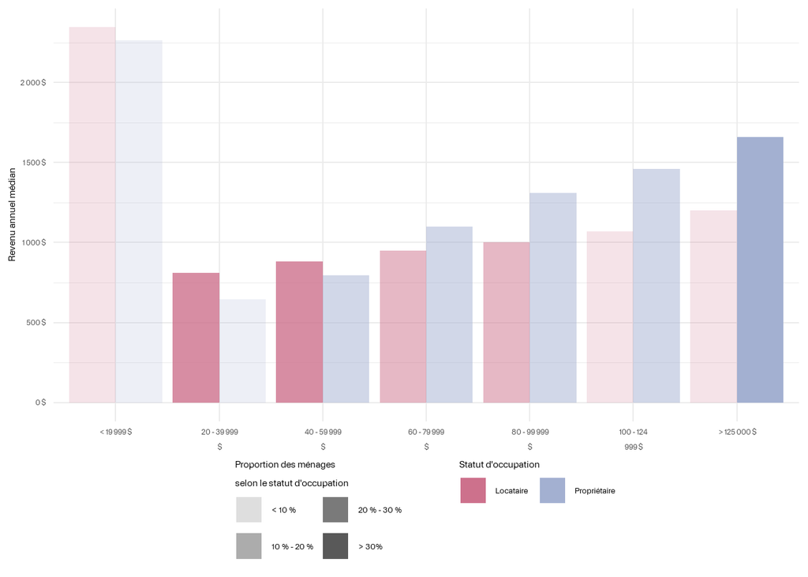

Frais médian de logement par statut d’occupation et tranches de revenu

# 4.2.5 4.2.5 Proportion de ménages, notamment locataires sous le seuil de faible revenu, consacrant plus de 30% et plus de 50% de leur revenu à se loger

Le graphique suivant montre la répartition des ménages lavallois selon le statut d’occupation, le pourcentage de revenu consacré aux frais de logement, et le statut de faible revenu. Il permet de visualiser les différences entre les ménages à faible revenu et l’ensemble des ménages pour chacune des trois tranches de taux d’effort pré-identifiées (moins de 30 %, 30 % ou plus, 50 % ou plus). Prendre en compte le statut de faible revenu est crucial pour évaluer le pourcentage de revenu consacré au logement, car cela met en évidence l’impact économique réel sur les ménages vulnérables. Une analyse par taux d’effort unique tout type de revenu confondu, comme le 30% communément admis, biaise la lecture. En effet, dépenser plus de 30 % du revenu en logement peut être supportable pour un ménage à revenu élevé, mais c’est une pression significative pour un ménage locataire à faible revenu, limitant leur capacité à couvrir d’autres besoins essentiels.

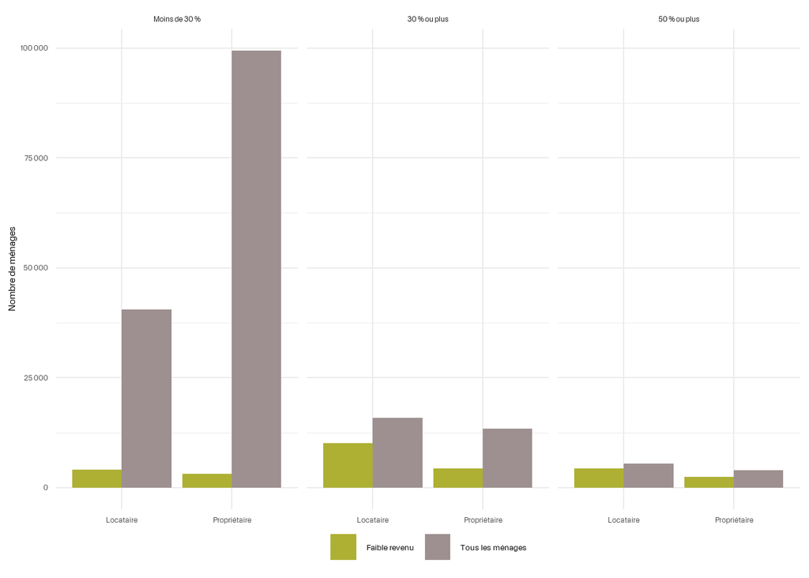

Distribution des ménages selon le statut d’occupation, le pourcentage de revenu consacré au logement et le statut de faible revenu

# 4.2.7 Ménages en situation de surpeuplement (axe “taille” de l’abordabilité)

Les secteurs du centre-sud de Laval, comme ceux entourant Chomedey, présentent une proportion plus élevée de ménages vivant dans un logement de taille non convenable. Ce phénomène peut être lié à la composition socio-économique de ces quartiers, qui comptent souvent plus de familles nombreuses ou à faible revenu, pour lesquelles il est plus difficile de trouver des logements adéquats.

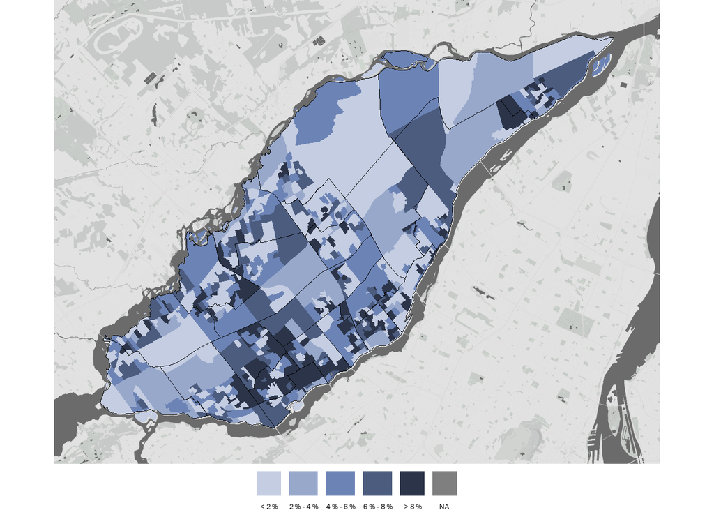

Proportion de ménages vivant dans un logement de taille non convenable

# 4.2.9 Ratio salaire hebdomadaire médian/paiement hypothécaire mensuel type

_Source: Portrait régional de l’habitation : 13 – Région administrative de Laval. (2020). Société d’habitation du Québec. Récupéré au https://www.habitation.gouv.qc.ca/fileadmin/internet/publications/portraits-regionaux/Portrait_habitation_region_13.pdf_

# 4.2.10 Frais de logement

*Source: SCHL*

Les coûts des loyers à Laval ont considérablement augmenté au cours de la dernière décennie. De 2010 à 2023, les loyers médians à Laval ont augmenté de 45,6 % en dollars courants. En 2023, le loyer médian à Laval était de 910 $. Le loyer médian cache par ailleurs la grande disparité de prix entre les logements locatifs occupés et inoccupés, les logements neufs et anciens et le prix selon le nombre de chambres à coucher.

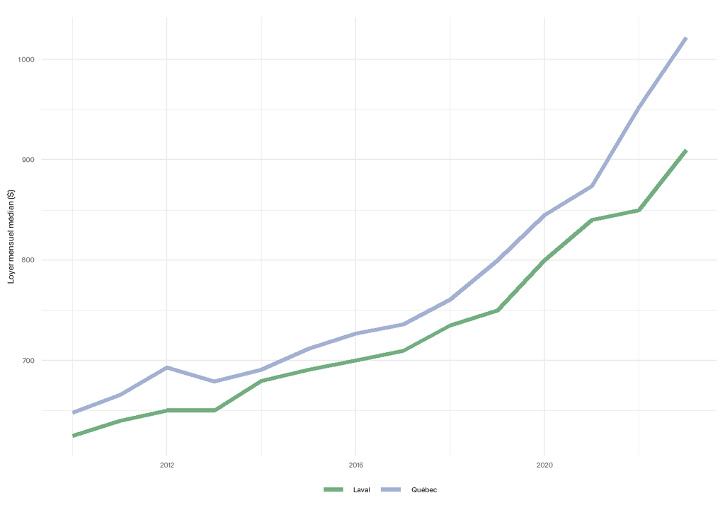

Évolution du loyer mensuel médian à Laval et au Québec (2010-2023)

Tout comme les coûts des loyers, les frais de logement des ménages propriétaires de Laval ont augmenté de façon importante. Selon le recensement de 2021, les frais de logement mensuels médians des propriétaires de Laval s’élevaient à 1 330 $, soit une augmentation de 11,8 % par rapport au 1 190 $ de 2016.

# 4.2.11 Aide au logement (aide à la pierre)

_Source: Observatoire Grand Montréal. (2024). Communauté métropolitaine de Montréal. Récupéré au https://observatoire.cmm.qc.ca/grand-montreal-en-statistiques/_

L’aide au logement à Laval regroupe plusieurs programmes offrant des logements subventionnés pour les ménages à faible ou modeste revenu, ainsi que ceux ayant des besoins particuliers.

Logements sociaux et communautaires financés par la CMM: 2 571 logements (2021) - Logements subventionnés par des programmes municipaux et gouvernementaux, destinés aux ménages à revenu modeste et aux clientèles ayant des besoins particuliers. Source: Société d’habitation du Québec (SHQ); Corporation d’habitation Jeanne-Mance (CHJM); Ville de Montréal. Traitement : CMM, 2021.

Logements gérés par des en coopératives d’habitation: 933 logements (2024) Source: Ville de Laval. (2024)

Logements gérés par des organismes à but non lucratif: 2065 logements (2024) Source: Ville de Laval. (2024)

Logements gérés par l’Office municipal d’habitation de Laval: 1 974 logements (2024) - Gérés par les Offices municipaux, ces logements sont destinés aux ménages à faible revenu, avec un loyer limité à 25 % du revenu familial. Source: Ville de Laval. (2024)

AccèsLogis Québec : 1 108 logements logements (2024) - Programme favorisant la création de coopératives et d’OBNL d’habitation, il cible les ménages à revenu modeste et, dans certaines conditions, offre aussi un Supplément au loyer (PSL). Source : Société d’habitation du Québec (SHQ), 2021.

Logements du programme LAQ - volet social et communautaire: 271 logements (2021) - Ce programme offre une aide financière pour stimuler la réalisation de logements abordables destinés aux ménages à revenu faible ou modeste. Source: Société d’habitation du Québec (SHQ), 2021.

Logements HLM privés et autochtones: 80 logements (2021) - Logements subventionnés pour les ménages à faible revenu, y compris ceux destinés aux Autochtones hors réserve, avec un loyer plafonné à 25 % du revenu. Source: Société d’habitation du Québec (SHQ), 2021.

[figure not shown]

# 4.2.12 Aide au paiement du loyer (aide à la personne)

_Source: Observatoire Grand Montréal. (2024). Communauté métropolitaine de Montréal. Récupéré au https://observatoire.cmm.qc.ca/grand-montreal-en-statistiques/_

Dans la Ville de Laval en 2021, il y avait 1 032 personnes qui bénéficiaient du programme Supplément au loyer (PSL). Ce programme “permet à des ménages à faible revenu d’habiter dans des logements qui font partie du marché locatif privé ou qui appartiennent à des coopératives d’habitation (COOP) ou à des organismes sans but lucratif (OSBL), tout en payant un loyer similaire à celui d’une habitation à loyer modique. Les locataires qui bénéficient de ce programme paient un loyer correspondant à 25 % de leur revenu.”[^1]

# 4.2.13 Délai d’attente moyen pour l’obtention d’un HLM public ou d’un supplément au loyer régulier ou autre logement subventionné

*Source: Délais d’attente moyen par territoire. (Juillet 2024). Office municipal d’habitation de Laval.*

Les délais d’attente pour obtenir un logement subventionné à Laval varient considérablement. Le délai moyen, tous programmes, territoires et clientèles confondues, est de 628 jours.

Parmi les clientèles visées, les familles affichent le délai moyen le plus élevé, atteignant 697 jours. Les personnes s’inscrivant aux programmes de 59 ans et moins attendent en moyenne 650 jours, tandis que pour celles dont la clientèle n’est pas spécifiée, le délai s’élève à 603 jours. Les individus s’inscrivant aux programmes pour les personnes âgées de 65 ans et plus bénéficient du délai moyen le plus court, avec une attente de 492 jours.

Cependant, bien que les aînés aient généralement le délai le plus court, ce groupe connaît également le délai d’attente le plus long dans le programme HLM à Chomedey sans fumée (60 ans et +), avec un maximum de 908 jours. À l’opposé, le délai le plus court se trouve dans le programme HLM du territoire 050 - SLO / PSL - Territoire Lavallois, avec une attente de seulement 54 jours. Le tableau suivant présente les délais moyens par programme.

[output not shown]

[^1]: Programme de supplément au loyer (PSL). (2024). Société d’habitation du Québec. Récupéré au https://www.habitation.gouv.qc.ca/programme/programme/programme-de-supplement-au-loyer-psl